# nmfspalette

[figure not shown]

An R color palette for `{ggplot2}` using NOAA Fisheries branding colors

[figure not shown]

`{nmfspalette}` implements these [steps](https://drsimonj.svbtle.com/creating-corporate-colour-palettes-for-ggplot2) to create a `{ggplot2}` compatible palette according to [NOAA Fisheries branding](https://drive.google.com/file/d/1lXHmfGWCj6pI_Dr3C-Dwcnf1pXOIOztp/view?usp=sharing) (NOAA internal only).

## Installation

To install from GitHub use the following:

```r
remotes::install_github("nmfs-ost/nmfspalette")
```

To load the package, use:

```r
library(nmfspalette)
```

## Contributing

We welcome contributions to `{nmfspalette}`. You are welcome to make any changes you would like on a fork and submit a pull request. For more substantial changes or to create a branch, please contact sophie.breitbart@noaa.gov (NOAA Affiliates only). We ask that all contributors adhere to The NOAA Fisheries Integrated Toolbox [code of conduct](https://github.com/nmfs-ost/Resources/blob/main/CONTRIBUTING.md).

## Usage

To learn how to use `nmfspalette`, please check out the [interactive `learnr` tutorial](https://connect.fisheries.noaa.gov/colors/).

Extract an interpolated color palette from the default “oceans” palette.

You can change the number of colors (10 shown below).

```r
nmfspalette::nmfs_palette("oceans")(10)
```

```
#>  [1] "#C6E6F0" "#8CCBE3" "#53B0D7" "#1F95CF" "#0072BB" "#004295" "#002B7B"
#>  [8] "#002467" "#001D55" "#001743"
```

## Palettes

To see the palettes, use the `display_nmfs_palette()` function.

### Main NOAA Fisheries palettes

These palettes contain 4 or 6 colors.

#### oceans

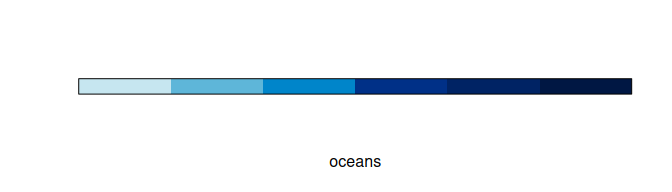

```r
nmfspalette::display_nmfs_palette("oceans", 6)
```

#### waves

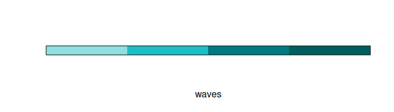

```r
nmfspalette::display_nmfs_palette("waves", 4)
```

#### seagrass

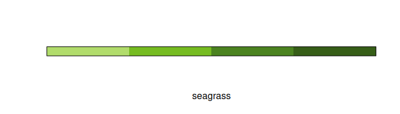

```r
nmfspalette::display_nmfs_palette("seagrass", 4)
```

#### urchin

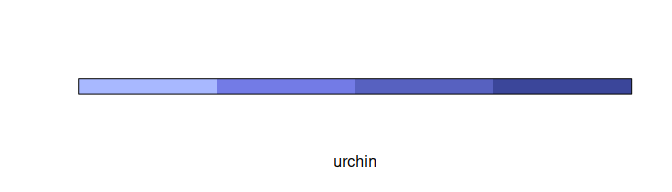

```r
nmfspalette::display_nmfs_palette("urchin", 4)
```

#### crustacean

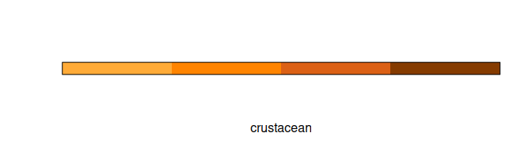

```r
nmfspalette::display_nmfs_palette("crustacean", 4)
```

#### coral

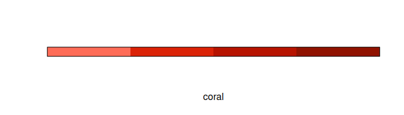

```r
nmfspalette::display_nmfs_palette("coral", 4)
```

#### regional (discrete)

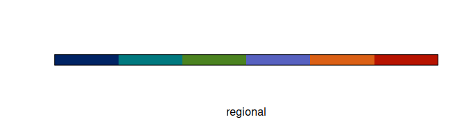

```r
nmfspalette::display_nmfs_palette("regional", 6)
```

##### Alternative regional palettes

For some with color vision deficiency (C.V.D.), it may be difficult to discern the colors in the regional palette. We have provided two alternative regional palettes, below. *Note*: The alternative palette 1 contains colors that are entirely within the NMFS brand color set; alternative palette 2 does not. However, the colors in alternative palette 1 may be less distinguishable for all types of color perception as opposed to alternative palette 2.

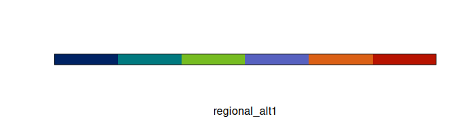

```r
nmfspalette::display_nmfs_palette("regional_alt1", 6)
```

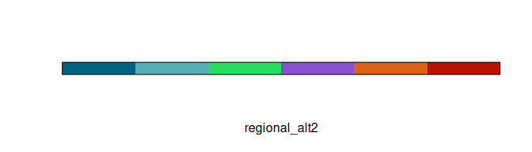

```r
nmfspalette::display_nmfs_palette("regional_alt2", 6)
```

### NOAA Fisheries complementary colors

These 5 palettes contain 4 complementary colors each and are identical to the main NOAA Fisheries palettes, but some colors have different names. Check out the [nmfs_cols.R file](https://github.com/nmfs-ost/nmfspalette/blob/main/R/nmfs_cols.R) for more information.

### NOAA Fisheries background & tint colors

These palettes contain 4 colors.

#### background sky

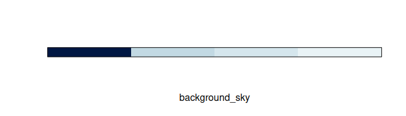

```r
nmfspalette::display_nmfs_palette("background_sky", 4)
```

#### background green

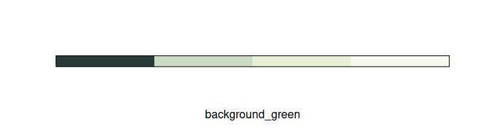

```r
nmfspalette::display_nmfs_palette("background_green", 4)
```

#### background gray

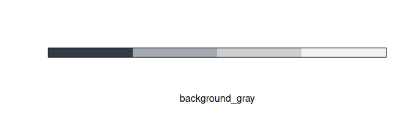

```r
nmfspalette::display_nmfs_palette("background_gray", 4)
```

### NOAA core colors (Fisheries version)

This palette contains 11 colors.

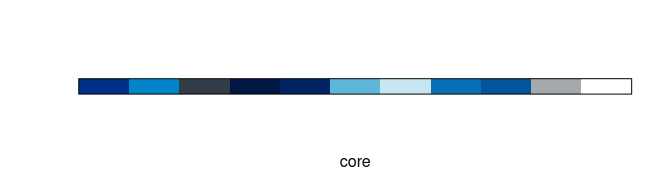

```r
nmfspalette::display_nmfs_palette("core", 11)
```

### NOAA alert colors

These palettes contain 4 colors.

#### alert red

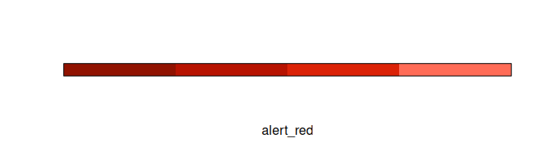

```r
nmfspalette::display_nmfs_palette("alert_red", 4)
```

#### alert orange

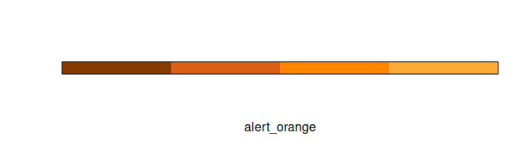

```r
nmfspalette::display_nmfs_palette("alert_orange", 4)
```

#### alert yellow

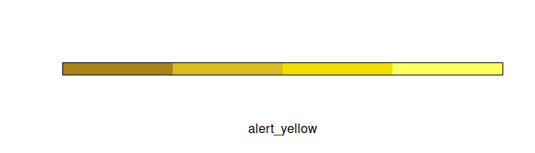

```r
nmfspalette::display_nmfs_palette("alert_yellow", 4)
```

#### alert green

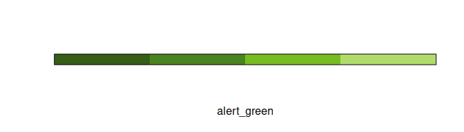

```r
nmfspalette::display_nmfs_palette("alert_green", 4)
```

## Examples

In addition to `nmfs_palette` and `display_nmfs_palette` to get palettes, you can extract colors by name. Please see the [NOAA Fisheries Branding guide](https://drive.google.com/file/d/1lXHmfGWCj6pI_Dr3C-Dwcnf1pXOIOztp/view?usp=sharing) (NOAA internal only) for color names. Here, for most color names, underscores are used in place of spaces. Colors defined before 2023 have no spaces in the color names.

```r
nmfspalette::nmfs_cols("vivid_crustacean")
```

```
#> vivid_crustacean
#>        "#FF8400"
```

```r
nmfspalette::nmfs_cols("processblue")
```

```
#> processblue
#>   "#0085CA"
```

To use the palettes with `{ggplot2}`, the `scale_color_nmfs()` and `scale_fill_nmfs()` functions are provided. If no argument is given to `scale_color_nmfs()`, a default (“oceans”) is used:

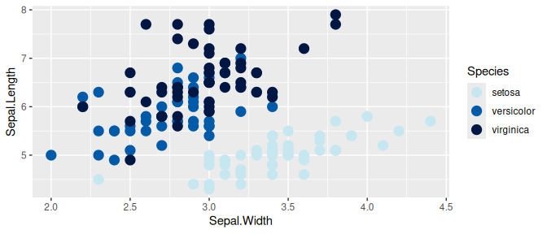

```r
p <- ggplot(iris, aes(Sepal.Width, Sepal.Length, color = Species)) +
  geom_point(size = 4) +
  scale_color_nmfs()
p
```

`scale_fill_nmfs()` does not have a default and therefore requires a named argument, this is an example using the “crustacean” palette:

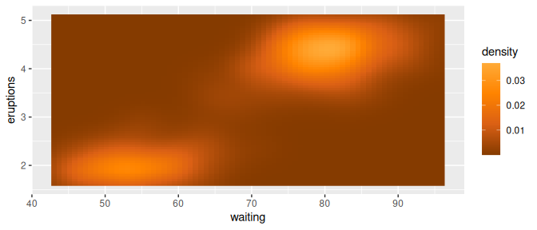

```r
ggplot(faithfuld, aes(waiting, eruptions)) +
  geom_raster(aes(fill = density)) +
  scale_fill_nmfs(palette = "crustacean", discrete = FALSE, reverse = TRUE)
```

## Disclaimer

“The United States Department of Commerce (DOC) GitHub project code is provided on an ‘as is’ basis and the user assumes responsibility for its use. DOC has relinquished control of the information and no longer has responsibility to protect the integrity, confidentiality, or availability of the information. Any claims against the Department of Commerce stemming from the use of its GitHub project will be governed by all applicable Federal law. Any reference to specific commercial products, processes, or services by service mark, trademark, manufacturer, or otherwise, does not constitute or imply their endorsement, recommendation or favoring by the Department of Commerce. The Department of Commerce seal and logo, or the seal and logo of a DOC bureau, shall not be used in any manner to imply endorsement of any commercial product or activity by DOC or the United States Government.”

[U.S. Department of Commerce](https://www.commerce.gov/) | [National Oceanographic and Atmospheric Administration](https://www.noaa.gov) | [NOAA Fisheries](https://www.fisheries.noaa.gov/)